# Kuan-I Lu Script

2024-10-23

## Benchmarked vs Modified Models Values

**Benchmark** 4 proteins sensitivity = 0.875 specificity = 0.8 accuracy = 0.839 roc_auc = 0.908

**Problem 3** **Part 1** 4 proteins sensitivity = 0.7692 accuracy = 0.6774 **Part 2** 13 proteins sensitivity = 0.8125 accuracy = 0.839 **Part 3** 6 proteins sensitivity = 0.75 accuracy = 0.7742

**Problem 4** **attempt 1: Correlation** 2 proteins accuracy = 0.613 **attempt 2: LASSO Regression** 3 proteins accuracy = 0.8710 (success)

## Problem 3

Load the pre-cleaned dataset from the data file

```r
library(tidyverse)
library(infer)
library(randomForest)
library(tidymodels)
library(modelr)
```

```r
library(yardstick)
library(ggplot2)
load('C:/D/homework/PSTAT 197/module1-group-11/data/biomarker-clean.RData')
```

Explore sensitivity with alternative methods

### Part 1

Partition the dataset first

```r
# partition 80% as training set, save as biomarker_train
set.seed(20251024)

biomarker_clean_split = biomarker_clean %>%
  initial_split(prop = 0.8)

biomarker_train = training(biomarker_clean_split)
biomarker_test = testing(biomarker_clean_split)
```

Then replicate the feature selecting process with the training dataset

- Obtain first panel, proteins_s1, with t-test

```r
# t-test
# Following code from inclass-analysis.R
# function to compute tests
test_fn <- function(.df){
  t_test(.df,
         formula = level ~ group,
         order = c('ASD', 'TD'),
         alternative = 'two-sided',
         var.equal = F)
}

ttests_out <- biomarker_train %>% ################ Use biomarker_train instead of biomarker_clean
  # drop ADOS score
  select(-ados) %>%
  # arrange in long format
  pivot_longer(-group,
               names_to = 'protein',
               values_to = 'level') %>%
  # nest by protein
  nest(data = c(level, group)) %>%
  # compute t tests
  mutate(ttest = map(data, test_fn)) %>%
  unnest(ttest) %>%
  # sort by p-value
  arrange(p_value) %>%
  # multiple testing correction
  mutate(m = n(),
         hm = log(m) + 1/(2*m) - digamma(1),
         rank = row_number(),
         p.adj = m*hm*p_value/rank)

# select significant proteins
proteins_s1 <- ttests_out %>%
  slice_min(p.adj, n = 10) %>% ########## Select 10 in this case
  pull(protein)
```

- Obtain second panel, proteins_s2, with random forest

```r
# Random forest
# store predictors and response separately
predictors <- biomarker_train %>% ############### Use biomarker_train instead of biomarker_clean
  select(-c(group, ados))

response <- biomarker_train %>% pull(group) %>% factor()

# fit RF
set.seed(20241024)
rf_out <- randomForest(x = predictors,
                       y = response,
                       ntree = 1000,
                       importance = T)

# compute importance scores
proteins_s2 <- rf_out$importance %>%
  as_tibble() %>%
  mutate(protein = rownames(rf_out$importance)) %>%
  slice_max(MeanDecreaseGini, n = 10) %>%
  pull(protein)
```

Obtain the intercept of the two panels and fit into logistic regression

```r
# Logistic Regression
# select subset of interest
proteins_sstar <- intersect(proteins_s1, proteins_s2)

biomarker_sstar <- biomarker_train %>% ##################  Use biomarker_train instead of biomarker_clean
  select(group, any_of(proteins_sstar)) %>%
  mutate(class = (group == 'ASD')) %>%
  select(-group)

biomarker_test = biomarker_test %>%
  select(group, any_of(proteins_sstar)) %>%
  mutate(class = (group == 'ASD')) %>%
  select(-group)

# fit logistic regression model to training set
fit <- glm(class ~ .,
           data = biomarker_sstar,
           family = 'binomial')


# evaluate errors on test set
##############  Use biomarker_test that we partitioned in the first step
class_metrics <- metric_set(sensitivity,
                            specificity,
                            accuracy,
                            roc_auc)

part_1_result = biomarker_test %>%
  add_predictions(fit, type = 'response') %>%
  mutate(est = as.factor(pred > 0.5), tr_c = as.factor(class)) %>%
  class_metrics(estimate = est,
              truth = tr_c, pred,
              event_level = 'second') %>%
  as.data.frame()

write_csv(part_1_result, "part_1_result.csv")
read_csv("part_1_result.csv")
```

```
## # A tibble: 4 × 3
##   .metric     .estimator .estimate
##   <chr>       <chr>          <dbl>
## 1 sensitivity binary         0.769
## 2 specificity binary         0.611
## 3 accuracy    binary         0.677
## 4 roc_auc     binary         0.778
```

The final panel has 4 proteins

After fitting the model trained on the training set on the testing set, our results has **sensitivity of 0.7692** and **accuracy of 0.6774**.

### Part 2

Not much modification from the in class analysis code but choose more than 10 variables for each panel. Here I choose 25 to allow a larger intercept values

```r
## MULTIPLE TESTING
####################

# function to compute tests
test_fn <- function(.df){
  t_test(.df,
         formula = level ~ group,
         order = c('ASD', 'TD'),
         alternative = 'two-sided',
         var.equal = F)
}

ttests_out <- biomarker_clean %>%
  # drop ADOS score
  select(-ados) %>%
  # arrange in long format
  pivot_longer(-group,
               names_to = 'protein',
               values_to = 'level') %>%
  # nest by protein
  nest(data = c(level, group)) %>%
  # compute t tests
  mutate(ttest = map(data, test_fn)) %>%
  unnest(ttest) %>%
  # sort by p-value
  arrange(p_value) %>%
  # multiple testing correction
  mutate(m = n(),
         hm = log(m) + 1/(2*m) - digamma(1),
         rank = row_number(),
         p.adj = m*hm*p_value/rank)

# select significant proteins
proteins_s1 <- ttests_out %>%
  slice_min(p.adj, n = 25) %>% ####################################### Select 25 instead of 10
  pull(protein)

## RANDOM FOREST
##################

# store predictors and response separately
predictors <- biomarker_clean %>%
  select(-c(group, ados))

response <- biomarker_clean %>% pull(group) %>% factor()

# fit RF
set.seed(101422)
rf_out <- randomForest(x = predictors,
                       y = response,
                       ntree = 1000,
                       importance = T)

# compute importance scores
proteins_s2 <- rf_out$importance %>%
  as_tibble() %>%
  mutate(protein = rownames(rf_out$importance)) %>%
  slice_max(MeanDecreaseGini, n = 25) %>% ############################# Select 25 instead of 10
  pull(protein)

## LOGISTIC REGRESSION
#######################

# select subset of interest
proteins_sstar <- intersect(proteins_s1, proteins_s2)

biomarker_sstar <- biomarker_clean %>%
  select(group, any_of(proteins_sstar)) %>%
  mutate(class = (group == 'ASD')) %>%
  select(-group)
```

Note that we have 13 proteins in our final panel, as opposed to the 4 protein panel with 10 protein from each methods

```r
# partition into training and test set
set.seed(101422)
biomarker_split <- biomarker_sstar %>%
  initial_split(prop = 0.8)

# fit logistic regression model to training set
fit <- glm(class ~ .,
           data = training(biomarker_split),
           family = 'binomial')

# evaluate errors on test set
class_metrics <- metric_set(sensitivity,
                            specificity,
                            accuracy,
                            roc_auc)

part_2_result = testing(biomarker_split) %>%
  add_predictions(fit, type = 'response') %>%
  mutate(est = as.factor(pred > 0.5), tr_c = as.factor(class)) %>%
  class_metrics(estimate = est,
              truth = tr_c, pred,
              event_level = 'second')

write_csv(part_2_result, "part_2_result.csv")
read_csv("part_2_result.csv")
```

```
## # A tibble: 4 × 3
##   .metric     .estimator .estimate
##   <chr>       <chr>          <dbl>
## 1 sensitivity binary         0.812
## 2 specificity binary         0.867
## 3 accuracy    binary         0.839
## 4 roc_auc     binary         0.946
```

After fitting the model trained on the training set on the testing set, our results has **sensitivity of 0.8125** and **accuracy of 0.8387**.

### Part 3

We essentially do the same thing as well, but use fuzzy intersection to create the final panel from the two 10-protein panels.

Before executing, We’re speculating if this modification would actually be useful since the name of the protein doesn’t really give out much information, but we will try regardless.

```r
## MULTIPLE TESTING
####################

# function to compute tests
test_fn <- function(.df){
  t_test(.df,
         formula = level ~ group,
         order = c('ASD', 'TD'),
         alternative = 'two-sided',
         var.equal = F)
}

ttests_out <- biomarker_clean %>%
  # drop ADOS score
  select(-ados) %>%
  # arrange in long format
  pivot_longer(-group,
               names_to = 'protein',
               values_to = 'level') %>%
  # nest by protein
  nest(data = c(level, group)) %>%
  # compute t tests
  mutate(ttest = map(data, test_fn)) %>%
  unnest(ttest) %>%
  # sort by p-value
  arrange(p_value) %>%
  # multiple testing correction
  mutate(m = n(),
         hm = log(m) + 1/(2*m) - digamma(1),
         rank = row_number(),
         p.adj = m*hm*p_value/rank)

# select significant proteins
proteins_s1 <- ttests_out %>%
  slice_min(p.adj, n = 10) %>%
  pull(protein)

## RANDOM FOREST
##################

# store predictors and response separately
predictors <- biomarker_clean %>%
  select(-c(group, ados))

response <- biomarker_clean %>% pull(group) %>% factor()

# fit RF
set.seed(101422)
rf_out <- randomForest(x = predictors,
                       y = response,
                       ntree = 1000,
                       importance = T)

# compute importance scores
proteins_s2 <- rf_out$importance %>%
  as_tibble() %>%
  mutate(protein = rownames(rf_out$importance)) %>%
  slice_max(MeanDecreaseGini, n = 10) %>%
  pull(protein)

## LOGISTIC REGRESSION
#######################

################################################################################# Use fuzzy intersect instead of intersect()
library(stringdist)
# Compute string distance matrix (using Levenshtein distance by default)
dist_matrix <- stringdistmatrix(proteins_s1, proteins_s2)

# Set a threshold for "closeness" (e.g., a maximum allowable distance of 2)
threshold <- 3 ######### Choose value based on the confusion matrix

# Find matches where the distance is below the threshold
fuzzy_matches <- which(dist_matrix <= threshold, arr.ind = TRUE)

# store all matching proteins in proteins_sstar and select the unique proteins
proteins_sstar = c()

for (match in 1:nrow(fuzzy_matches)) {
  proteins_sstar = c(proteins_sstar, proteins_s1[fuzzy_matches[match, 1]], proteins_s2[fuzzy_matches[match, 2]])
}

proteins_sstar = proteins_sstar %>% unique()

###################################################################################
```

We have 6 proteins in our final panel, as opposed to the 4 protein panel with exact matching

```r
biomarker_sstar <- biomarker_clean %>%
  select(group, any_of(proteins_sstar)) %>%
  mutate(class = (group == 'ASD')) %>%
  select(-group)

# partition into training and test set
set.seed(101422)
biomarker_split <- biomarker_sstar %>%
  initial_split(prop = 0.8)

# fit logistic regression model to training set
fit <- glm(class ~ .,
           data = training(biomarker_split),
           family = 'binomial')

# evaluate errors on test set
class_metrics <- metric_set(sensitivity,
                            specificity,
                            accuracy,
                            roc_auc)

part_3_result = testing(biomarker_split) %>%
  add_predictions(fit, type = 'response') %>%
  mutate(est = as.factor(pred > 0.5), tr_c = as.factor(class)) %>%
  class_metrics(estimate = est,
              truth = tr_c, pred,
              event_level = 'second')

write_csv(part_3_result, "part_3_result.csv")
read_csv("part_3_result.csv")
```

```
## # A tibble: 4 × 3
##   .metric     .estimator .estimate
##   <chr>       <chr>          <dbl>
## 1 sensitivity binary         0.75
## 2 specificity binary         0.8
## 3 accuracy    binary         0.774
## 4 roc_auc     binary         0.858
```

After fitting the model trained on the training set on the testing set, our results has **sensitivity of 0.75** and **accuracy of 0.7742**. As expected, fuzzy match did not improve the results

## Problem 4

Goal: a simpler panel that achieves comparable classification accuracy (0.839). *Note: only focus on accuracy*

The benchmarked panel already only has 4 proteins, so we have to come up with a panel that has less than 4 preteins, either based on the current panel or other feature selection methods

Ideas: Correlation, LASSO regression, Solely random forest, Elastic Net, Correlation

### Attempt 1, Correlation

Let’s try Correlation first

```r
# Correlation
# partition 80% as training set, save as biomarker_train
set.seed(20251024)

biomarker_clean_split = biomarker_clean %>%
  initial_split(prop = 0.8)

biomarker_train = training(biomarker_clean_split)
biomarker_test = testing(biomarker_clean_split)

# Only get observation in group "ASD"
biomarker_train_asd = biomarker_train %>%
  filter(group == "ASD") %>%
  select(-group)

# compute correlations and select top three proteins with highest absolute values of correlation
proteins_sstar = biomarker_train_asd %>%
  pivot_longer(cols = -ados,
               names_to = 'protein',
               values_to = 'level') %>%
  group_by(protein) %>%
  summarize(correlation = cor(ados, level)) %>%
  mutate(abs_corr = abs(correlation)) %>%
  slice_max(order_by = abs_corr, n = 2) %>%
  pull(protein)
```

We have constructed a panel of 2 proteins based on the highest absolute value of correlation.

```r
biomarker_sstar <- biomarker_clean %>%
  select(group, any_of(proteins_sstar)) %>%
  mutate(class = (group == 'ASD')) %>%
  select(-group)

# partition into training and test set
set.seed(20241024)
biomarker_split <- biomarker_sstar %>%
  initial_split(prop = 0.8)

# fit logistic regression model to training set
fit <- glm(class ~ .,
           data = training(biomarker_split),
           family = 'binomial')

# evaluate errors on test set
class_metrics <- metric_set(accuracy)

method_1_result = testing(biomarker_split) %>%
  add_predictions(fit, type = 'response') %>%
  mutate(est = as.factor(pred > 0.5), tr_c = as.factor(class)) %>%
  class_metrics(estimate = est,
              truth = tr_c, pred,
              event_level = 'second') %>%
  as.data.frame()

write_csv(method_1_result, "method_1_result.csv")
read_csv("method_1_result.csv")
```

```
## # A tibble: 1 × 3
##   .metric  .estimator .estimate
##   <chr>    <chr>          <dbl>
## 1 accuracy binary         0.613
```

The accuracy of the model is 0.613, which is far from the goal.

### Attempt 2: LASSO Regression

Now lets try LASSO Regression

```r
# LASSO regression
library(glmnet)
```

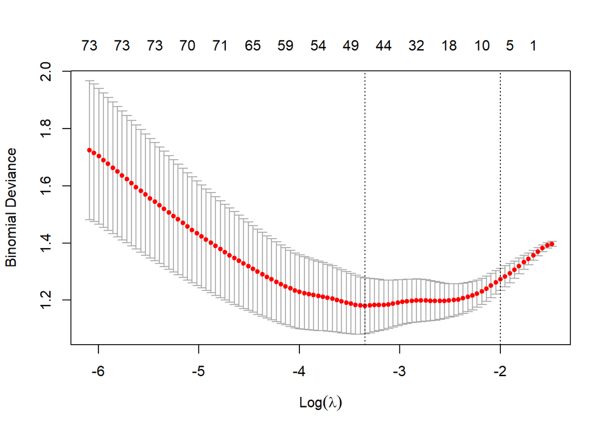

```r
# create class variable
biomarker_LASSO = biomarker_clean %>%
  select(-ados) %>%
  mutate(class = as.numeric(group == 'ASD'))

set.seed(101622)
partitions <- biomarker_LASSO %>%
  initial_split(prop = 0.8)

x_train <- training(partitions) %>%
  select(-group, -class) %>%
  as.matrix()
y_train <- training(partitions) %>%
  pull(class)

# tune and fit the LASSO model
plot(cv.glmnet(x_train, y_train, family = 'binomial', type.measure = 'deviance'))
```

```r
# Choose a reasonable lambda value based on the plot, with the goal of reducing to less than 4 proteins
lambda = exp(-1.8)

# Fit again
final_fit <- glmnet(x_train, y_train, family = 'binomial', lambda = lambda)
final_fit_df = tidy(final_fit)

# Extract the core proteins
proteins_sstar = final_fit_df %>%
  filter(term != "(Intercept)") %>%
  pull(term)
```

Note that we have constructed a panel with 3 proteins

```r
biomarker_sstar <- biomarker_clean %>%
  select(group, any_of(proteins_sstar)) %>%
  mutate(class = (group == 'ASD')) %>%
  select(-group)

# partition into training and test set
set.seed(1024)
biomarker_split <- biomarker_sstar %>%
  initial_split(prop = 0.8)

# fit logistic regression model to training set
fit <- glm(class ~ .,
           data = training(biomarker_split),
           family = 'binomial')

# evaluate errors on test set
class_metrics <- metric_set(accuracy)

method_2_result = testing(biomarker_split) %>%
  add_predictions(fit, type = 'response') %>%
  mutate(est = as.factor(pred > 0.5), tr_c = as.factor(class)) %>%
  class_metrics(estimate = est,
              truth = tr_c, pred,
              event_level = 'second')

write_csv(method_2_result, "method_2_result.csv")
read_csv("method_2_result.csv")
```

```
## # A tibble: 1 × 3
##   .metric  .estimator .estimate
##   <chr>    <chr>          <dbl>
## 1 accuracy binary         0.871
```

With feature selection using LASSO regression, we’ve successfully created a panel of 3 proteins (“MAPK2”, “IgD”, and “DERM” ) that, when fit into a logistic regression, reaches accuracy of **0.8710**

## Flowchart for writeups

[output not shown]